# Analysis of Air Quality in New York City

By: Mahinsa Bambarende

## Introduction

Air quality refers to the level of pollutants present in the air, which can come from a variety of sources including transportation, industry, and natural sources such as wildfires. Poor air quality can have serious health consequences, particularly for vulnerable populations such as children, the elderly, and those with pre-existing respiratory conditions. It can also lead to environmental damage, such as acid rain and climate change. By monitoring and improving air quality, we can help to protect both human health and the environment, and create a more sustainable future for all.

Air quality is a critical issue that affects the health of residents in urban areas such as New York City. Pollution from traffic, industry, and other sources can have serious health consequences, making it crucial to analyze air quality data to understand the extent of the problem and identify potential solutions.

In this tutorial, we will use Python and various libraries to collect, process, and analyze air quality data for NYC. By exploring the data using visualization techniques and statistical analysis, we aim to identify trends and patterns of air quality in the city.

The ultimate goal of our analysis is to draw conclusions and provide reasoning for improving air quality in NYC. Policymakers can use our findings to develop targeted interventions that reduce pollution and improve public health. As individuals, analyzing air quality data can raise awareness and encourage people to take action to reduce their own contribution to pollution through sustainable practices like using public transportation or reducing energy consumption.

Throughout this tutorial, we will follow the Data Science Lifecycle:

1. Data Collection
2. Data Processing
3. Exploratory Analysis & Data Visualization
4. Model: Analysis, Hypothesis Testing, & ML
5. Interpretation: Insight & Policy Decision

By the end of this tutorial, you will have a better understanding of how to use data analysis techniques to address real-world environmental challenges and make informed policy decisions.

## Data Collection

The first step in our analysis of air quality in NYC is data collection. To conduct a thorough analysis, we need reliable and comprehensive data on air quality in the city. In this stage, we will identify data sources, gather data, and prepare it for analysis.

There are several data sources available for air quality data in NYC, including the Environmental Protection Agency (EPA) and the New York State Department of Environmental Conservation (DEC). These organizations provide data on various air pollutants such as sulfur dioxide, ozone, nitrogen dioxide, and particulate matter, among others.

We will be using the NYC Environment and Health Data Portal as our primary data source and can be obtained [here](https://catalog.data.gov/dataset/air-quality)

But before that, to start here are all the libraries going to be used in this tutorial.

```python
import pandas as pd
import matplotlib.pyplot as plt
import numpy as np

from sklearn.linear_model import LinearRegression, RANSACRegressor
from sklearn.model_selection import train_test_split
from sklearn.metrics import mean_squared_error, r2_score

import folium
import datetime
import seaborn as sns
```

Our first step is to import our air quality data. We do this by using the pandas function read_csv which takes in the data from the csv file and places it in a dataframe. Notice how all the important data like hospitalizations and greenhouse gas emissions are clumped into one table, making it hard to understand what the data is conveying. This is where the data processing step is introduced to help clean the data to become more useful in our analysis.

```python
data = pd.read_csv("Air_Quality.csv")
data
```

|  | Unique ID | Indicator ID | Name | Measure | Measure Info | Geo Type Name | Geo Join ID | Geo Place Name | Time Period | Start_Date | Data Value | Message |
| --- | --- | --- | --- | --- | --- | --- | --- | --- | --- | --- | --- | --- |
| 0 | 216498 | 386 | Ozone (O3) | Mean | ppb | CD | 313 | Coney Island (CD13) | Summer 2013 | 06/01/2013 | 34.64 | NaN |
| 1 | 216499 | 386 | Ozone (O3) | Mean | ppb | CD | 313 | Coney Island (CD13) | Summer 2014 | 06/01/2014 | 33.22 | NaN |
| 2 | 219969 | 386 | Ozone (O3) | Mean | ppb | Borough | 1 | Bronx | Summer 2013 | 06/01/2013 | 31.25 | NaN |
| 3 | 219970 | 386 | Ozone (O3) | Mean | ppb | Borough | 1 | Bronx | Summer 2014 | 06/01/2014 | 31.15 | NaN |
| 4 | 164876 | 383 | Sulfur Dioxide (SO2) | Mean | ppb | CD | 211 | Morris Park and Bronxdale (CD11) | Winter 2008-09 | 12/01/2008 | 5.89 | NaN |
| ... | ... | ... | ... | ... | ... | ... | ... | ... | ... | ... | ... | ... |
| 16117 | 671118 | 386 | Ozone (O3) | Mean | ppb | CD | 306 | Park Slope and Carroll Gardens (CD6) | Summer 2020 | 06/01/2020 | 28.70 | NaN |
| 16118 | 671119 | 386 | Ozone (O3) | Mean | ppb | CD | 305 | East New York and Starrett City (CD5) | Summer 2020 | 06/01/2020 | 29.56 | NaN |
| 16119 | 671120 | 386 | Ozone (O3) | Mean | ppb | CD | 304 | Bushwick (CD4) | Summer 2020 | 06/01/2020 | 29.65 | NaN |
| 16120 | 671121 | 386 | Ozone (O3) | Mean | ppb | CD | 303 | Bedford Stuyvesant (CD3) | Summer 2020 | 06/01/2020 | 29.28 | NaN |
| 16121 | 671122 | 386 | Ozone (O3) | Mean | ppb | CD | 302 | Fort Greene and Brooklyn Heights (CD2) | Summer 2020 | 06/01/2020 | 28.93 | NaN |

16122 rows × 12 columns

In addition we are going to be using a map later on for visualization so lets load the data for that too. This dataframe contains all boroughs, neigborhoods, and their coordinates which can help when we get to the visualization step. You can obtain the data through: https://github.com/nychealth/EHDP-data/blob/production/geography/GeoLookup.csv

```python
map = pd.read_csv("GeoLookup.csv")
map.head()
```

|  | GeoType | GeoTypeDesc | GeoTypeShortDesc | GeoID | Name | BoroID | Borough | Lat | Long |
| --- | --- | --- | --- | --- | --- | --- | --- | --- | --- |
| 0 | Citywide | Citywide | Citywide | 1 | New York City | NaN | NaN | NaN | NaN |
| 1 | Borough | Borough | Borough | 1 | Bronx | 1.0 | Bronx | 40.8526 | -73.8665 |
| 2 | Borough | Borough | Borough | 2 | Brooklyn | 2.0 | Brooklyn | 40.6447 | -73.9479 |
| 3 | Borough | Borough | Borough | 3 | Manhattan | 3.0 | Manhattan | 40.7772 | -73.9672 |
| 4 | Borough | Borough | Borough | 4 | Queens | 4.0 | Queens | 40.7076 | -73.8185 |

## Data Processing

Once we have collected the air quality data for NYC, the next step is to process the data to make it ready for analysis. Data processing involves a series of tasks to clean, transform, and aggregate the raw data into a more usable format. By performing these data processing tasks, we can ensure that our data is consistent, complete, and in a format that is suitable for analysis. This will help us to gain insights into the factors affecting air quality in NYC and develop strategies for improving it.

To start this step, let's begin by cleaning and seperating the data to become more useful for us. Let's drop the message column as it seems to be empty throughout. Instead of having the start date, let's change that column to show the year that this data is reflecting.

Additionally, let's list all the unique names in the Name table to help determine how we are cleaning the data.

```python
data = data.drop(['Message'], axis=1)
data['Start_Date'] = pd.to_datetime(data['Start_Date'], format='%m/%d/%Y')
data['Year'] = data['Start_Date'].dt.year

# Fixes one of dates as the start of 2016 begins on the last day of 2015
x = datetime.datetime(2015, 12, 31).date()
data.loc[data['Start_Date'].dt.date == x, 'Year'] = 2016
data = data.drop(['Start_Date'], axis=1)
names = data.Name.unique()
names
```

```
array(['Ozone (O3)', 'Sulfur Dioxide (SO2)', 'PM2.5-Attributable Deaths',
       'Boiler Emissions- Total SO2 Emissions',
       'Boiler Emissions- Total PM2.5 Emissions',
       'Boiler Emissions- Total NOx Emissions',
       'Air Toxics Concentrations- Average Benzene Concentrations',
       'Air Toxics Concentrations- Average Formaldehyde Concentrations',
       'PM2.5-Attributable Asthma Emergency Department Visits',
       'PM2.5-Attributable Respiratory Hospitalizations (Adults 20 Yrs and Older)',
       'PM2.5-Attributable Cardiovascular Hospitalizations (Adults 40 Yrs and Older)',
       'Traffic Density- Annual Vehicle Miles Traveled',
       'O3-Attributable Cardiac and Respiratory Deaths',
       'O3-Attributable Asthma Emergency Department Visits',
       'O3-Attributable Asthma Hospitalizations',
       'Traffic Density- Annual Vehicle Miles Traveled for Cars',
       'Traffic Density- Annual Vehicle Miles Traveled for Trucks',
       'Nitrogen Dioxide (NO2)', 'Fine Particulate Matter (PM2.5)'],
      dtype=object)
```

Now we can see how we might split the data to seperate tables. Notice how all of this information is clumped into one table. It's best if we sepearte them and set them to become useful. Let's first get the data for each type of pollutant. To begin first set a table for mean Ozone levels in NYC.

Let's also drop some of the columns as they hold unnecessary information like Measure, Measure Info, and Indicator ID. This is because they are the same throughout what we are seperating.

We'll also use some of the map data to set the lattitutdes and longitudes for easier visualization.

```python
# set up the lattitudes and longitutdes for the data
data['Lat'] = np.nan
data['Long'] = np.nan

for i, row  in map.iterrows():
    data['Lat'] = np.where(data['Geo Join ID'] == row['GeoID'], row['Lat'], data['Lat'])
    data['Long'] = np.where(data['Geo Join ID'] == row['GeoID'], row['Long'], data['Long'])
data
```

|  | Unique ID | Indicator ID | Name | Measure | Measure Info | Geo Type Name | Geo Join ID | Geo Place Name | Time Period | Data Value | Year | Lat | Long |
| --- | --- | --- | --- | --- | --- | --- | --- | --- | --- | --- | --- | --- | --- |
| 0 | 216498 | 386 | Ozone (O3) | Mean | ppb | CD | 313 | Coney Island (CD13) | Summer 2013 | 34.64 | 2013 | 40.5806 | -73.9821 |
| 1 | 216499 | 386 | Ozone (O3) | Mean | ppb | CD | 313 | Coney Island (CD13) | Summer 2014 | 33.22 | 2014 | 40.5806 | -73.9821 |
| 2 | 219969 | 386 | Ozone (O3) | Mean | ppb | Borough | 1 | Bronx | Summer 2013 | 31.25 | 2013 | 40.8092 | -73.8991 |
| 3 | 219970 | 386 | Ozone (O3) | Mean | ppb | Borough | 1 | Bronx | Summer 2014 | 31.15 | 2014 | 40.8092 | -73.8991 |
| 4 | 164876 | 383 | Sulfur Dioxide (SO2) | Mean | ppb | CD | 211 | Morris Park and Bronxdale (CD11) | Winter 2008-09 | 5.89 | 2008 | 40.8561 | -73.8528 |
| ... | ... | ... | ... | ... | ... | ... | ... | ... | ... | ... | ... | ... | ... |
| 16117 | 671118 | 386 | Ozone (O3) | Mean | ppb | CD | 306 | Park Slope and Carroll Gardens (CD6) | Summer 2020 | 28.70 | 2020 | 40.6764 | -73.9945 |
| 16118 | 671119 | 386 | Ozone (O3) | Mean | ppb | CD | 305 | East New York and Starrett City (CD5) | Summer 2020 | 29.56 | 2020 | 40.6685 | -73.8797 |
| 16119 | 671120 | 386 | Ozone (O3) | Mean | ppb | CD | 304 | Bushwick (CD4) | Summer 2020 | 29.65 | 2020 | 40.6945 | -73.9168 |
| 16120 | 671121 | 386 | Ozone (O3) | Mean | ppb | CD | 303 | Bedford Stuyvesant (CD3) | Summer 2020 | 29.28 | 2020 | 40.6877 | -73.9406 |
| 16121 | 671122 | 386 | Ozone (O3) | Mean | ppb | CD | 302 | Fort Greene and Brooklyn Heights (CD2) | Summer 2020 | 28.93 | 2020 | 40.6935 | -73.9787 |

16122 rows × 13 columns

```python
O3 = data[data['Name'] == 'Ozone (O3)']
O3 = O3.drop(['Measure', 'Measure Info', 'Indicator ID', 'Name'], axis=1)
O3 = O3.reset_index(drop=True)
O3
```

|  | Unique ID | Geo Type Name | Geo Join ID | Geo Place Name | Time Period | Data Value | Year | Lat | Long |
| --- | --- | --- | --- | --- | --- | --- | --- | --- | --- |
| 0 | 216498 | CD | 313 | Coney Island (CD13) | Summer 2013 | 34.64 | 2013 | 40.5806 | -73.9821 |
| 1 | 216499 | CD | 313 | Coney Island (CD13) | Summer 2014 | 33.22 | 2014 | 40.5806 | -73.9821 |
| 2 | 219969 | Borough | 1 | Bronx | Summer 2013 | 31.25 | 2013 | 40.8092 | -73.8991 |
| 3 | 219970 | Borough | 1 | Bronx | Summer 2014 | 31.15 | 2014 | 40.8092 | -73.8991 |
| 4 | 219971 | Borough | 2 | Brooklyn | Summer 2009 | 26.27 | 2009 | 40.8454 | -73.8876 |
| ... | ... | ... | ... | ... | ... | ... | ... | ... | ... |
| 1687 | 671118 | CD | 306 | Park Slope and Carroll Gardens (CD6) | Summer 2020 | 28.70 | 2020 | 40.6764 | -73.9945 |
| 1688 | 671119 | CD | 305 | East New York and Starrett City (CD5) | Summer 2020 | 29.56 | 2020 | 40.6685 | -73.8797 |
| 1689 | 671120 | CD | 304 | Bushwick (CD4) | Summer 2020 | 29.65 | 2020 | 40.6945 | -73.9168 |
| 1690 | 671121 | CD | 303 | Bedford Stuyvesant (CD3) | Summer 2020 | 29.28 | 2020 | 40.6877 | -73.9406 |
| 1691 | 671122 | CD | 302 | Fort Greene and Brooklyn Heights (CD2) | Summer 2020 | 28.93 | 2020 | 40.6935 | -73.9787 |

1692 rows × 9 columns

Then Sulfur Dioxide

```python
SO2 = data[data['Name'] == 'Sulfur Dioxide (SO2)']
SO2 = SO2.drop(['Measure', 'Measure Info', 'Indicator ID', 'Name'], axis=1)
SO2 = SO2.reset_index(drop=True)
SO2
```

|  | Unique ID | Geo Type Name | Geo Join ID | Geo Place Name | Time Period | Data Value | Year | Lat | Long |
| --- | --- | --- | --- | --- | --- | --- | --- | --- | --- |
| 0 | 164876 | CD | 211 | Morris Park and Bronxdale (CD11) | Winter 2008-09 | 5.89 | 2008 | 40.8561 | -73.8528 |
| 1 | 164877 | CD | 212 | Williamsbridge and Baychester (CD12) | Winter 2008-09 | 5.75 | 2008 | 40.8863 | -73.8515 |
| 2 | 164878 | CD | 301 | Greenpoint and Williamsburg (CD1) | Winter 2008-09 | 4.33 | 2008 | 40.7168 | -73.9472 |
| 3 | 164879 | CD | 302 | Fort Greene and Brooklyn Heights (CD2) | Winter 2008-09 | 4.41 | 2008 | 40.6935 | -73.9787 |
| 4 | 164880 | CD | 303 | Bedford Stuyvesant (CD3) | Winter 2008-09 | 4.73 | 2008 | 40.6877 | -73.9406 |
| ... | ... | ... | ... | ... | ... | ... | ... | ... | ... |
| 1123 | 405357 | CD | 413 | Queens Village (CD13) | Winter 2015-16 | 0.26 | 2015 | 40.6996 | -73.7373 |
| 1124 | 405358 | CD | 414 | Rockaway and Broad Channel (CD14) | Winter 2015-16 | 0.20 | 2015 | 40.5891 | -73.8103 |
| 1125 | 405359 | CD | 501 | St. George and Stapleton (CD1) | Winter 2015-16 | 0.13 | 2015 | 40.8427 | -73.9003 |
| 1126 | 405360 | CD | 502 | South Beach and Willowbrook (CD2) | Winter 2015-16 | 0.12 | 2015 | 40.8132 | -73.8881 |
| 1127 | 405361 | CD | 503 | Tottenville and Great Kills (CD3) | Winter 2015-16 | 0.11 | 2015 | 40.8809 | -73.8366 |

1128 rows × 9 columns

Nitrogen Dioxide

```python
NO2 = data[data['Name'] == 'Nitrogen Dioxide (NO2)']
NO2 = NO2.drop(['Measure', 'Measure Info', 'Indicator ID', 'Name'], axis=1)
NO2 = NO2.reset_index(drop=True)
NO2
```

|  | Unique ID | Geo Type Name | Geo Join ID | Geo Place Name | Time Period | Data Value | Year | Lat | Long |
| --- | --- | --- | --- | --- | --- | --- | --- | --- | --- |
| 0 | 165739 | CD | 101 | Financial District (CD1) | Winter 2008-09 | 41.26 | 2008 | 40.7074 | -74.0120 |
| 1 | 165740 | CD | 102 | Greenwich Village and Soho (CD2) | Winter 2008-09 | 39.68 | 2008 | 40.7298 | -74.0015 |
| 2 | 165741 | CD | 103 | Lower East Side and Chinatown (CD3) | Winter 2008-09 | 36.88 | 2008 | 40.7196 | -73.9855 |
| 3 | 165742 | CD | 104 | Clinton and Chelsea (CD4) | Winter 2008-09 | 40.88 | 2008 | 40.7554 | -73.9975 |
| 4 | 165743 | CD | 105 | Midtown (CD5) | Winter 2008-09 | 50.56 | 2008 | 40.7523 | -73.9841 |
| ... | ... | ... | ... | ... | ... | ... | ... | ... | ... |
| 5071 | 667862 | CD | 502 | South Beach and Willowbrook (CD2) | Winter 2019-20 | 18.24 | 2019 | 40.8132 | -73.8881 |
| 5072 | 667863 | CD | 502 | South Beach and Willowbrook (CD2) | Summer 2020 | 7.50 | 2020 | 40.8132 | -73.8881 |
| 5073 | 667867 | CD | 503 | Tottenville and Great Kills (CD3) | Annual Average 2020 | 10.49 | 2020 | 40.8809 | -73.8366 |
| 5074 | 667868 | CD | 503 | Tottenville and Great Kills (CD3) | Winter 2019-20 | 15.11 | 2019 | 40.8809 | -73.8366 |
| 5075 | 667869 | CD | 503 | Tottenville and Great Kills (CD3) | Summer 2020 | 7.32 | 2020 | 40.8809 | -73.8366 |

5076 rows × 9 columns

And finally, Fine Particles

```python
PM2 = data[data['Name'] == 'Fine Particulate Matter (PM2.5)']
PM2 = PM2.drop(['Measure', 'Measure Info', 'Indicator ID', 'Name'], axis=1)
PM2 = PM2.reset_index(drop=True)
PM2
```

|  | Unique ID | Geo Type Name | Geo Join ID | Geo Place Name | Time Period | Data Value | Year | Lat | Long |
| --- | --- | --- | --- | --- | --- | --- | --- | --- | --- |
| 0 | 168394 | CD | 101 | Financial District (CD1) | Winter 2008-09 | 15.74 | 2008 | 40.7074 | -74.0120 |
| 1 | 168395 | CD | 102 | Greenwich Village and Soho (CD2) | Winter 2008-09 | 15.21 | 2008 | 40.7298 | -74.0015 |
| 2 | 168396 | CD | 103 | Lower East Side and Chinatown (CD3) | Winter 2008-09 | 14.24 | 2008 | 40.7196 | -73.9855 |
| 3 | 168397 | CD | 104 | Clinton and Chelsea (CD4) | Winter 2008-09 | 15.48 | 2008 | 40.7554 | -73.9975 |
| 4 | 168398 | CD | 105 | Midtown (CD5) | Winter 2008-09 | 18.84 | 2008 | 40.7523 | -73.9841 |
| ... | ... | ... | ... | ... | ... | ... | ... | ... | ... |
| 5071 | 669980 | CD | 502 | South Beach and Willowbrook (CD2) | Winter 2019-20 | 6.89 | 2019 | 40.8132 | -73.8881 |
| 5072 | 669981 | CD | 502 | South Beach and Willowbrook (CD2) | Summer 2020 | 6.55 | 2020 | 40.8132 | -73.8881 |
| 5073 | 669982 | CD | 503 | Tottenville and Great Kills (CD3) | Annual Average 2020 | 5.32 | 2020 | 40.8809 | -73.8366 |
| 5074 | 669983 | CD | 503 | Tottenville and Great Kills (CD3) | Winter 2019-20 | 5.95 | 2019 | 40.8809 | -73.8366 |
| 5075 | 669984 | CD | 503 | Tottenville and Great Kills (CD3) | Summer 2020 | 6.52 | 2020 | 40.8809 | -73.8366 |

5076 rows × 9 columns

Let's also get the asthma data Ozone first and then PM2.5

```python
O3_asthma = data[data['Name'] == 'O3-Attributable Asthma Emergency Department Visits']
O3_asthma = O3_asthma.reset_index(drop=True)
O3_asthma
```

|  | Unique ID | Indicator ID | Name | Measure | Measure Info | Geo Type Name | Geo Join ID | Geo Place Name | Time Period | Data Value | Year | Lat | Long |
| --- | --- | --- | --- | --- | --- | --- | --- | --- | --- | --- | --- | --- | --- |
| 0 | 131027 | 653 | O3-Attributable Asthma Emergency Department Vi... | Estimated Annual Rate- Children 0 to 17 Yrs Old | per 100,000 children | UHF42 | 101 | Kingsbridge - Riverdale | 2005-2007 | 68.3 | 2005 | 40.7074 | -74.0120 |
| 1 | 131028 | 653 | O3-Attributable Asthma Emergency Department Vi... | Estimated Annual Rate- Children 0 to 17 Yrs Old | per 100,000 children | UHF42 | 102 | Northeast Bronx | 2005-2007 | 114.5 | 2005 | 40.7298 | -74.0015 |
| 2 | 131029 | 653 | O3-Attributable Asthma Emergency Department Vi... | Estimated Annual Rate- Children 0 to 17 Yrs Old | per 100,000 children | UHF42 | 103 | Fordham - Bronx Pk | 2005-2007 | 115.8 | 2005 | 40.7196 | -73.9855 |
| 3 | 131030 | 653 | O3-Attributable Asthma Emergency Department Vi... | Estimated Annual Rate- Children 0 to 17 Yrs Old | per 100,000 children | UHF42 | 104 | Pelham - Throgs Neck | 2005-2007 | 114.6 | 2005 | 40.7554 | -73.9975 |
| 4 | 131031 | 653 | O3-Attributable Asthma Emergency Department Vi... | Estimated Annual Rate- Children 0 to 17 Yrs Old | per 100,000 children | UHF42 | 105 | Crotona -Tremont | 2005-2007 | 159.6 | 2005 | 40.7523 | -73.9841 |
| ... | ... | ... | ... | ... | ... | ... | ... | ... | ... | ... | ... | ... | ... |
| 379 | 628955 | 659 | O3-Attributable Asthma Emergency Department Vi... | Estimated Annual Rate- 18 Yrs and Older | per 100,000 adults | UHF42 | 501 | Port Richmond | 2015-2017 | 74.6 | 2015 | 40.8427 | -73.9003 |
| 380 | 628956 | 659 | O3-Attributable Asthma Emergency Department Vi... | Estimated Annual Rate- 18 Yrs and Older | per 100,000 adults | UHF42 | 502 | Stapleton - St. George | 2015-2017 | 53.8 | 2015 | 40.8132 | -73.8881 |
| 381 | 628957 | 659 | O3-Attributable Asthma Emergency Department Vi... | Estimated Annual Rate- 18 Yrs and Older | per 100,000 adults | UHF42 | 503 | Willowbrook | 2015-2017 | 21.4 | 2015 | 40.8809 | -73.8366 |
| 382 | 628958 | 659 | O3-Attributable Asthma Emergency Department Vi... | Estimated Annual Rate- 18 Yrs and Older | per 100,000 adults | UHF42 | 504 | South Beach - Tottenville | 2015-2017 | 13.9 | 2015 | 40.8329 | -73.9211 |
| 383 | 628959 | 659 | O3-Attributable Asthma Emergency Department Vi... | Estimated Annual Rate- 18 Yrs and Older | per 100,000 adults | Citywide | 1 | New York City | 2015-2017 | 48.3 | 2015 | 40.8092 | -73.8991 |

384 rows × 13 columns

```python
PM2_asthma = data[data['Name'] == 'PM2.5-Attributable Asthma Emergency Department Visits']
PM2_asthma = PM2_asthma.reset_index(drop=True)
PM2_asthma
```

|  | Unique ID | Indicator ID | Name | Measure | Measure Info | Geo Type Name | Geo Join ID | Geo Place Name | Time Period | Data Value | Year | Lat | Long |
| --- | --- | --- | --- | --- | --- | --- | --- | --- | --- | --- | --- | --- | --- |
| 0 | 130787 | 648 | PM2.5-Attributable Asthma Emergency Department... | Estimated Annual Rate- Children 0 to 17 Yrs Old | per 100,000 children | UHF42 | 101 | Kingsbridge - Riverdale | 2005-2007 | 88.3 | 2005 | 40.7074 | -74.0120 |
| 1 | 130788 | 648 | PM2.5-Attributable Asthma Emergency Department... | Estimated Annual Rate- Children 0 to 17 Yrs Old | per 100,000 children | UHF42 | 102 | Northeast Bronx | 2005-2007 | 152.6 | 2005 | 40.7298 | -74.0015 |
| 2 | 130789 | 648 | PM2.5-Attributable Asthma Emergency Department... | Estimated Annual Rate- Children 0 to 17 Yrs Old | per 100,000 children | UHF42 | 103 | Fordham - Bronx Pk | 2005-2007 | 167.2 | 2005 | 40.7196 | -73.9855 |
| 3 | 130790 | 648 | PM2.5-Attributable Asthma Emergency Department... | Estimated Annual Rate- Children 0 to 17 Yrs Old | per 100,000 children | UHF42 | 104 | Pelham - Throgs Neck | 2005-2007 | 162.5 | 2005 | 40.7554 | -73.9975 |
| 4 | 130791 | 648 | PM2.5-Attributable Asthma Emergency Department... | Estimated Annual Rate- Children 0 to 17 Yrs Old | per 100,000 children | UHF42 | 105 | Crotona -Tremont | 2005-2007 | 257.1 | 2005 | 40.7523 | -73.9841 |
| ... | ... | ... | ... | ... | ... | ... | ... | ... | ... | ... | ... | ... | ... |
| 379 | 628523 | 657 | PM2.5-Attributable Asthma Emergency Department... | Estimated Annual Rate- 18 Yrs and Older | per 100,000 adults | UHF42 | 501 | Port Richmond | 2015-2017 | 45.6 | 2015 | 40.8427 | -73.9003 |
| 380 | 628524 | 657 | PM2.5-Attributable Asthma Emergency Department... | Estimated Annual Rate- 18 Yrs and Older | per 100,000 adults | UHF42 | 502 | Stapleton - St. George | 2015-2017 | 32.0 | 2015 | 40.8132 | -73.8881 |
| 381 | 628525 | 657 | PM2.5-Attributable Asthma Emergency Department... | Estimated Annual Rate- 18 Yrs and Older | per 100,000 adults | UHF42 | 503 | Willowbrook | 2015-2017 | 12.9 | 2015 | 40.8809 | -73.8366 |
| 382 | 628526 | 657 | PM2.5-Attributable Asthma Emergency Department... | Estimated Annual Rate- 18 Yrs and Older | per 100,000 adults | UHF42 | 504 | South Beach - Tottenville | 2015-2017 | 9.2 | 2015 | 40.8329 | -73.9211 |
| 383 | 628527 | 657 | PM2.5-Attributable Asthma Emergency Department... | Estimated Annual Rate- 18 Yrs and Older | per 100,000 adults | Citywide | 1 | New York City | 2015-2017 | 34.6 | 2015 | 40.8092 | -73.8991 |

384 rows × 13 columns

We will also be using annual traffic densities. So let us also get that.

```python
traffic = data[data['Name'] == 'Traffic Density- Annual Vehicle Miles Traveled']
traffic = traffic.drop(['Measure', 'Measure Info', 'Indicator ID', 'Name'], axis=1)
traffic = traffic.reset_index(drop=True)
traffic
```

|  | Unique ID | Geo Type Name | Geo Join ID | Geo Place Name | Time Period | Data Value | Year | Lat | Long |
| --- | --- | --- | --- | --- | --- | --- | --- | --- | --- |
| 0 | 154594 | CD | 311 | Bensonhurst (CD11) | 2005 | 19.1 | 2005 | 40.6072 | -73.9936 |
| 1 | 151623 | UHF42 | 101 | Kingsbridge - Riverdale | 2005 | 24.6 | 2005 | 40.7074 | -74.0120 |
| 2 | 151624 | UHF42 | 102 | Northeast Bronx | 2005 | 16.7 | 2005 | 40.7298 | -74.0015 |
| 3 | 151625 | UHF42 | 103 | Fordham - Bronx Pk | 2005 | 23.8 | 2005 | 40.7196 | -73.9855 |
| 4 | 151626 | UHF42 | 104 | Pelham - Throgs Neck | 2005 | 22.8 | 2005 | 40.7554 | -73.9975 |
| ... | ... | ... | ... | ... | ... | ... | ... | ... | ... |
| 204 | 325295 | CD | 413 | Queens Village (CD13) | 2016 | 30.8 | 2016 | 40.6996 | -73.7373 |
| 205 | 325296 | CD | 414 | Rockaway and Broad Channel (CD14) | 2016 | 6.9 | 2016 | 40.5891 | -73.8103 |
| 206 | 325297 | CD | 501 | St. George and Stapleton (CD1) | 2016 | 11.3 | 2016 | 40.8427 | -73.9003 |
| 207 | 325298 | CD | 502 | South Beach and Willowbrook (CD2) | 2016 | 11.8 | 2016 | 40.8132 | -73.8881 |
| 208 | 325299 | CD | 503 | Tottenville and Great Kills (CD3) | 2016 | 6.5 | 2016 | 40.8809 | -73.8366 |

209 rows × 9 columns

## Exploratory Analysis & Data Visualization

The next step, we will use exploratory analysis and data visualization techniques to explore and understand air quality data for NYC. Exploratory analysis involves summarizing and visualizing the data in various ways to identify patterns, trends, and relationships between variables. Data visualization, on the other hand, involves creating visual representations of the data, such as charts, graphs, and maps, that enable us to explore and communicate the insights and patterns we have discovered. These techniques help us to understand the data better, identify potential outliers and anomalies, and guide the development of predictive models.

```python
def plot_pollutant (df, ylabel, pollutant):
    places = ['New York City', 'Bronx', 'Brooklyn', 'Manhattan', 'Staten Island']
    place_plots = df[df["Geo Place Name"].isin(places)]
    place_plots.set_index('Year', inplace=True)
    place_plots = place_plots.sort_values('Year')
    place_plots.groupby("Geo Place Name")['Data Value'].plot(legend= True)

    plt.ylabel(ylabel)
    plt.title(pollutant + ' Levels over Time')
    plt.show()

    # makes the boxplots
    sns.boxplot(x='Year', y='Data Value', data=O3)
    plt.ylabel(ylabel)
    plt.title("Box Plot of " + pollutant + " Levels over Time")
    plt.show()
```

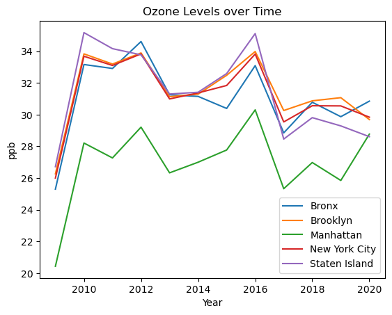

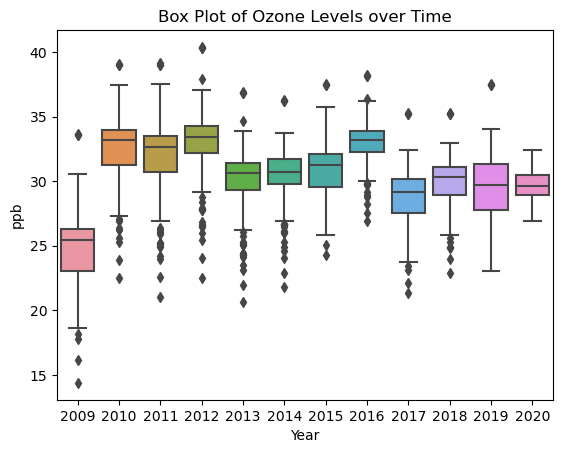

```python
plot_pollutant(O3, 'ppb', 'Ozone')
```

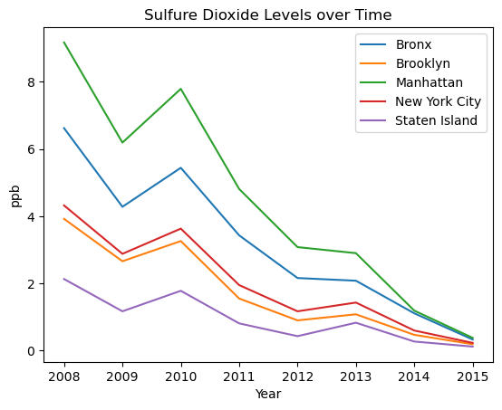

[figure not shown]

```python
plot_pollutant(SO2, 'ppb', 'Sulfure Dioxide')
```

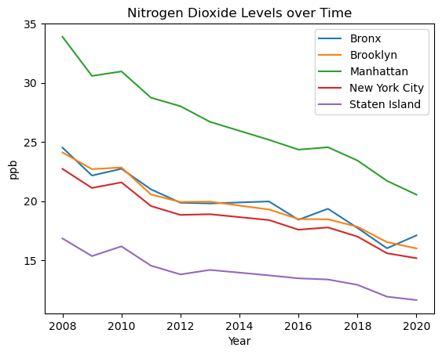

[figure not shown]

```python
NO2_annual = NO2[NO2["Time Period"].str.contains("Annual")]
plot_pollutant(NO2_annual, 'ppb', 'Nitrogen Dioxide')
```

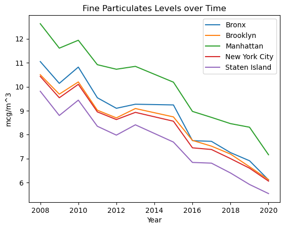

[figure not shown]

```python
PM2_annual = PM2[PM2["Time Period"].str.contains("Annual")]
plot_pollutant(PM2_annual, 'mcg/m^3', 'Fine Particulates')
```

For now, even though we visualized the averages of the whole city, it is hard to tell where the worst is. And also how much has this impacted the people living there.

Let's begin by seeing the different levels of pollutants throughout the different neighborhoods. We can accomplish this using [Folium](https://python-visualization.github.io/folium/), a Python library for creating interactive maps, which will allow us to see the levels of pollutants in each neighborhood and how they vary across the city.

To start and simplify things lets make two functions. The first determines the color of a marker with red being the worst levels, yellow is in the middle and green as the best in the city. The second function does the actual mapping by taking a data frame of a type of pollutant and marking their amounts in the different neighborhoods using the color_producer to help visualize the severity.

```python
# sets the color of each marker depending on where it is in the range of values
def color_producer(ammount, min, max):
    temp = (max-min)/3
    if max-temp < ammount <= max :
        return 'red'
    elif max-(2*temp) < ammount <= max-temp :
        return 'yellow'
    elif min <= ammount <= max-(2*temp):
        return 'green'
    else:
        return 'gray'

def map_maker (df, min, max, colName):
    nyc_map = folium.Map(location=[40.7128, -74.0060], zoom_start=10)

    # Add markers for each location
    for index, row in df.iterrows():
        lat = row['Lat']
        lon = row['Long']
        name = row['Geo Place Name']
        folium.CircleMarker(
            location=[lat, lon],
            radius=7,
            fill = True,
            fill_opacity = 0.5,
            color = color_producer(row[colName],min, max),
            opacity = 0.4,
            popup=name
        ).add_to(nyc_map)
    return nyc_map
```

Now all that is left is to use the most recent data and plot each pollutant on the map of NYC.

```python
O3_CD = O3[O3['Time Period'] == 'Summer 2019']
map_maker(O3_CD, min(O3_CD['Data Value']), max(O3_CD['Data Value']), 'Data Value')
```

Make this Notebook Trusted to load map: File -> Trust Notebook

[interactive chart not shown]

```python
SO2_CD = SO2[SO2['Time Period'] == 'Winter 2015-16']
map_maker(SO2_CD, min(SO2_CD['Data Value']), max(SO2_CD['Data Value']), 'Data Value')
```

Make this Notebook Trusted to load map: File -> Trust Notebook

[interactive chart not shown]

```python
NO2_CD = NO2[NO2['Time Period'] == 'Annual Average 2019']
map_maker(NO2_CD, min(NO2_CD['Data Value']), max(NO2_CD['Data Value']), 'Data Value')
```

Make this Notebook Trusted to load map: File -> Trust Notebook

[interactive chart not shown]

```python
PM2_CD = PM2[PM2['Time Period'] == 'Annual Average 2019']
map_maker(PM2_CD, min(PM2_CD['Data Value']), max(PM2_CD['Data Value']), 'Data Value')
```

Make this Notebook Trusted to load map: File -> Trust Notebook

[interactive chart not shown]

Interesting. Observe how the Ozone levels are the most severe outside of the middle of the city compared to the other pollutants who are the most severe in the middle. It might be interesting to research more about Ozone and sources that could contribute to its increase compared to other pollutants.

Ozone (O3) and PM2.5 are two of the most commonly monitored air pollutants, and they are known to be harmful to human health. Since we have the data for asthma emergency visits due to Ozone and PM2.5, lets visualize the two to see if we can confirm a relationship between the ozone levels and asthma.

Similar to plotting the ozone levels and PM2 levels over time, let's do the same for asthma emergency visits. Let's create a function that helps avoid repeating code but also plot this.

```python
def plot_asthma (df, pollutant):
    asthma = df.copy()
    asthma.rename(columns={'Data Value': 'Emergency Visits'}, inplace = True)

    asthma_adults = asthma[asthma['Measure'] == 'Estimated Annual Rate- 18 Yrs and Older']
    asthma_child = asthma[asthma['Measure'] == 'Estimated Annual Rate- Children 0 to 17 Yrs Old']

    # plots the adults data
    place_plots = asthma_adults[asthma_adults["Geo Place Name"].isin(places)]
    place_plots.set_index('Year', inplace=True)
    place_plots = place_plots.sort_values('Year')
    place_plots.groupby("Geo Place Name")['Emergency Visits'].plot(legend= True)

    # sets titles and labels
    title = 'Asthma Emergency Visits of Adults by ' + pollutant + ' in NYC (2005-2015)'
    plt.ylabel('Asthma Emergency Visits (per 100,000 adults)')
    plt.title(title)
    plt.show()

    # plots the children data
    place_plots = asthma_child[asthma_child["Geo Place Name"].isin(places)]
    place_plots.set_index('Year', inplace=True)
    place_plots = place_plots.sort_values('Year')
    place_plots.groupby("Geo Place Name")['Emergency Visits'].plot(legend= True)

     # sets titles and labels
    title = 'Asthma Emergency Visits of Children by ' + pollutant + ' in NYC (2005-2015)'
    plt.ylabel('Asthma Emergency Visits (per 100,000 children)')
    plt.title(title)
    plt.show()
```

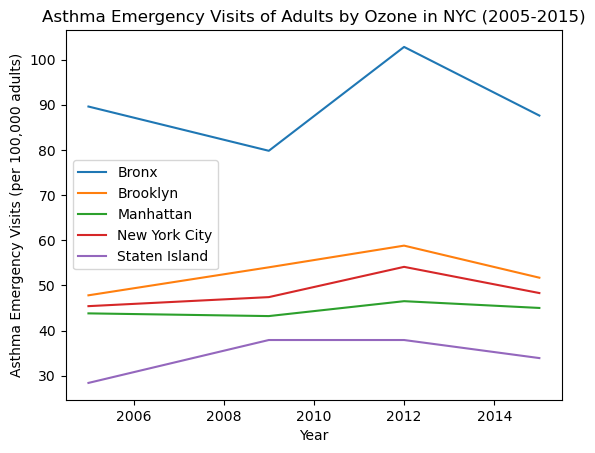

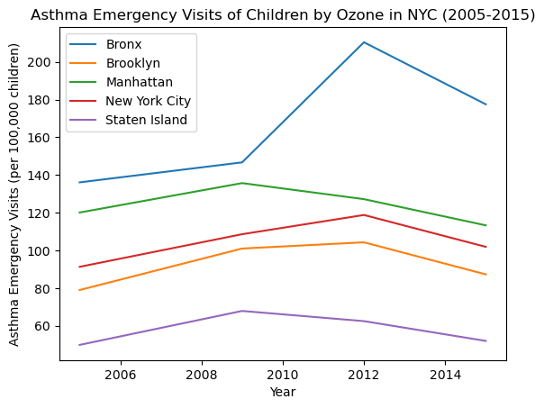

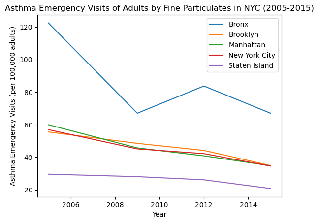

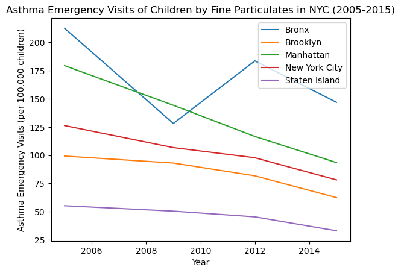

```python
plot_asthma(O3_asthma, 'Ozone')
plot_asthma(PM2_asthma, 'Fine Particulates')
```

Let us also make a scatter plot plotting each neighborhood and its ozone level and asthma emergency visits. This is done by first setting up the two data sets and combining them using merge().

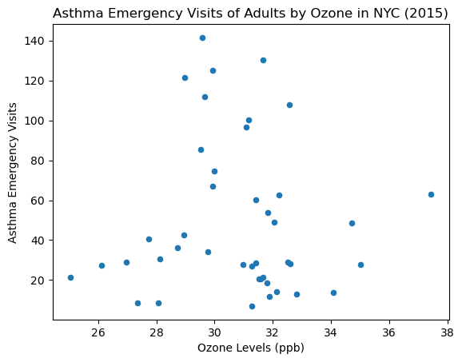

```python
years = [2015]
df = O3[O3['Geo Type Name'] == 'UHF42']
df = df[df["Year"].isin(years)]

asthma_adults = O3_asthma[O3_asthma['Measure'] == 'Estimated Annual Rate- 18 Yrs and Older']
df2 = asthma_adults[asthma_adults['Geo Type Name'] == 'UHF42']
df2 = df2[df2["Year"].isin(years)]

df = df.sort_values('Geo Place Name')
df = df.reset_index(drop=True)
df = df.drop(["Time Period", 'Geo Type Name', 'Unique ID', 'Lat', 'Long', 'Year'], axis=1)
df.rename(columns={'Data Value': 'Levels'}, inplace = True)

df2 = df2.sort_values('Geo Place Name')
df2 = df2.reset_index(drop=True)
df2 = df2.drop(['Measure', 'Measure Info', 'Indicator ID', 'Name', 'Time Period',
                'Geo Type Name', 'Unique ID', 'Year'], axis=1)
df2.rename(columns={'Data Value': 'Asthma Emergency Visits'}, inplace = True)

O3_joined = df.merge(df2, on=['Geo Join ID', 'Geo Place Name'])
O3_joined.plot.scatter('Levels', 'Asthma Emergency Visits')

# gives appropriate labels and title
plt.xlabel('Ozone Levels (ppb)')
plt.ylabel('Asthma Emergency Visits')
plt.title('Asthma Emergency Visits of Adults by Ozone in NYC (2015)')
plt.show()
```

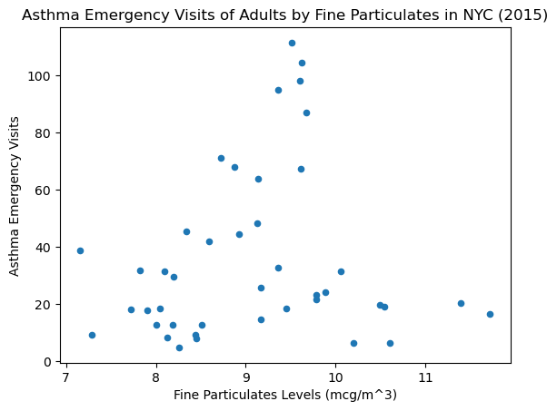

```python
years = [2015]
df = PM2[PM2['Geo Type Name'] == 'UHF42']
df = df[df["Time Period"].str.contains("Annual")]
df = df[df["Year"].isin(years)]

asthma_adults = PM2_asthma[PM2_asthma['Measure'] == 'Estimated Annual Rate- 18 Yrs and Older']
df2 = asthma_adults[asthma_adults['Geo Type Name'] == 'UHF42']
df2 = df2[df2["Year"].isin(years)]

df = df.sort_values('Geo Place Name')
df = df.reset_index(drop=True)
df = df.drop(["Time Period", 'Geo Type Name', 'Unique ID', 'Lat', 'Long', 'Year'], axis=1)
df.rename(columns={'Data Value': 'Levels'}, inplace = True)

df2 = df2.sort_values('Geo Place Name')
df2 = df2.reset_index(drop=True)
df2 = df2.drop(['Measure', 'Measure Info', 'Indicator ID', 'Name', 'Time Period',
                'Geo Type Name', 'Unique ID', 'Year'], axis=1)
df2.rename(columns={'Data Value': 'Asthma Emergency Visits'}, inplace = True)

PM2_joined = df.merge(df2, on=['Geo Join ID', 'Geo Place Name'])
PM2_joined.plot.scatter('Levels', 'Asthma Emergency Visits')

plt.xlabel('Fine Particulates Levels (mcg/m^3)')
plt.ylabel('Asthma Emergency Visits')
plt.title('Asthma Emergency Visits of Adults by Fine Particulates in NYC (2015)')
plt.show()
```

It seems that the Bronx has the highest amounts of hospitalizations due to Ozone and fine particulates. And we can also see that the amount of emergency visits are much higher for children than adults. But it is hard to see that relationship between the pollutants and emergency visits. This is where the modeling stage plays an important role to help find trends and patterns but to help create predictions outside of the scope of this data. But before that let us look at one of the sources of fine particulate emissions.

A study published in the journal [Scientific Reports](https://www.nature.com/articles/s41598-021-00862-x#:~:text=Abstract,sources%20of%20PM2.5%20emission.) in 2021 found that transportation was the largest source of PM2.5 in the United States, contributing to more than 50% of the total emissions.

And according to the [INRIX Global Traffic Scorecard](https://inrix.com/scorecard/), New York City was ranked the fifth most congested city in the world in 2022. So let us visualize and later find a relationship between NYC traffic densities and PM2.5 levels.

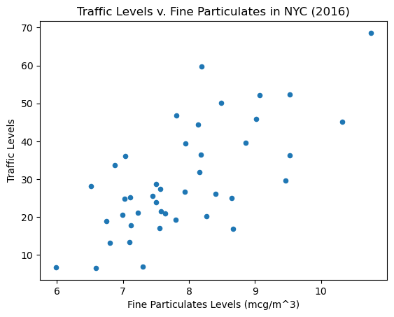

```python
years = [2016]
df = PM2[PM2['Geo Type Name'] == 'UHF42']
df = df[df["Time Period"].str.contains("Annual")]
df = df[df["Year"].isin(years)]

df2 = traffic[traffic['Geo Type Name'] == 'UHF42']
df2 = df2[df2["Year"].isin(years)]

df = df.sort_values('Geo Place Name')
df = df.reset_index(drop=True)
df = df.drop(["Time Period", 'Geo Type Name', 'Unique ID', 'Lat', 'Long', 'Year'], axis=1)
df.rename(columns={'Data Value': 'PM2 Levels'}, inplace = True)

df2 = df2.sort_values('Geo Place Name')
df2 = df2.reset_index(drop=True)
df2 = df2.drop(['Time Period','Geo Type Name', 'Unique ID','Lat', 'Long', 'Year'], axis=1)
df2.rename(columns={'Data Value': 'Traffic Levels'}, inplace = True)

traffic_joined = df.merge(df2, on=['Geo Join ID', 'Geo Place Name'])
traffic_joined.plot.scatter('PM2 Levels', 'Traffic Levels')

plt.xlabel('Fine Particulates Levels (mcg/m^3)')
plt.ylabel('Traffic Levels')
plt.title('Traffic Levels v. Fine Particulates in NYC (2016)')
plt.show()
```

## Model: Analysis, Hypothesis Testing, & ML

The modeling step is a crucial component of the data science lifecycle. Once the data has been collected, cleaned, and preprocessed, the next step is to create a model that can be used to make predictions or gain a better understanding of the underlying relationships between variables.

While the data that we have so far is good, it does not help to determine how severe the issue is today as it only goes until 2020. Let's create linear regression model to predict the air quality outside the scope of our data.

To begin let's create a function that creates a linear regression model using the ordinary least squares method. OLS finds the line that best fits the data by minimizing the distance between the predicted values and the actual values. The coefficients of the linear equation are then estimated using this line.

```python
def leastSquares (df, X, Y, xlabel, ylabel, title):

    # Split the data into training and testing sets
    X_train, X_test, Y_train, Y_test = train_test_split(X, Y, test_size=0.3)

    # Create a linear regression model
    model = LinearRegression()

    # Train the model on the training data
    model.fit(X_train, Y_train)

    # Compute the predicted values for the training and testing sets
    Y_train_pred = model.predict(X_train)
    Y_test_pred = model.predict(X_test)

    print('Ordinary Least Squares (OLS)')
    print('Coefficients: ', model.coef_[0])
    print('Intercept: ', model.intercept_)
    print('Mean squared error: %.2f' % mean_squared_error(Y_test, Y_test_pred))
    print('Coefficient of determination: %.2f' % r2_score(Y_test, Y_test_pred))

    plt.scatter(X_train, Y_train, color='blue', label='Training Data')
    plt.scatter(X_test, Y_test, color='red', label='Testing Data')
    plt.plot(X_train, Y_train_pred, color='black', linewidth=2, label='Regression Line')
    plt.xlabel(xlabel)
    plt.ylabel(ylabel)
    plt.title(title)
    plt.legend()
    plt.show()
```

Also we can define a function that uses Random Sample Consensus (RANSAC). RANSAC is an iterative algorithm used to estimate the parameters of a mathematical model from a set of data points. It is useful in situations where the data set contains a large number of outliers, which can significantly affect the estimation of the model parameters. By iteratively fitting the model to subsets of the data that contain fewer outliers, RANSAC can provide more robust estimates of the model parameters than traditional methods like least squares regression.

We can see the difference between the two once we start getting the line of regression for the different data sets.

```python
def RANSAC (df, X, Y, xlabel, ylabel, title):
    # Split the data into training and testing sets
    X_train, X_test, Y_train, Y_test = train_test_split(X, Y, test_size=0.3)

    ransac = linear_model.RANSACRegressor()

    # Fit the model to the training data
    ransac.fit(X_train, Y_train)

    # Make predictions on the testing data
    Y_pred = ransac.predict(X_test)

    print('RANSAC')
    print('Coefficients: ', ransac.estimator_.coef_[0])
    print('Intercept: ', ransac.estimator_.intercept_)
    print('Mean squared error: %.2f' % mean_squared_error(Y_test, Y_pred))
    print('Coefficient of determination: %.2f' % r2_score(Y_test, Y_pred))

    # Plot the regression line and the data
    fig, ax = plt.subplots()
    inlier_mask = ransac.inlier_mask_
    outlier_mask = np.logical_not(inlier_mask)
    ax.scatter(X_train[inlier_mask], Y_train[inlier_mask], label='Inliers')
    ax.scatter(X_train[outlier_mask], Y_train[outlier_mask], label='Outliers')
    ax.plot(X_test, Y_pred, color='black', label='RANSAC regression')
    plt.xlabel(xlabel)
    plt.ylabel(ylabel)
    plt.title(title)
    ax.legend()
    plt.show()
```

To start, let's find the line of regression for the different pollutants that we used in the visualization step.

```
Ordinary Least Squares (OLS)
Coefficients:  [0.01104027]
Intercept:  [8.15625278]
Mean squared error: 11.86
Coefficient of determination: -0.00
```

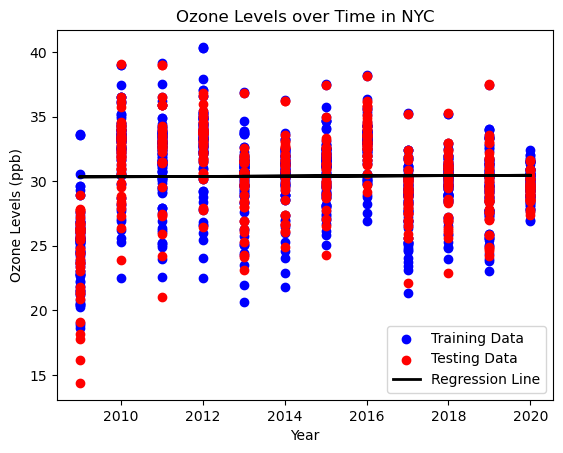

```
RANSAC
Coefficients:  [-0.38074576]
Intercept:  [798.42141256]
Mean squared error: 12.44
Coefficient of determination: -0.22
```

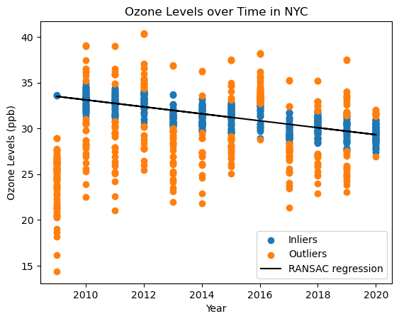

```python
X = O3[['Year']]
Y = O3[['Data Value']]
leastSquares(O3, X, Y, 'Year', 'Ozone Levels (ppb)', 'Ozone Levels over Time in NYC')
RANSAC(O3, X, Y, 'Year', 'Ozone Levels (ppb)', 'Ozone Levels over Time in NYC')
```

```
Ordinary Least Squares (OLS)
Coefficients:  [-0.7407587]
Intercept:  [1492.65980241]
Mean squared error: 2.43
Coefficient of determination: 0.50
```

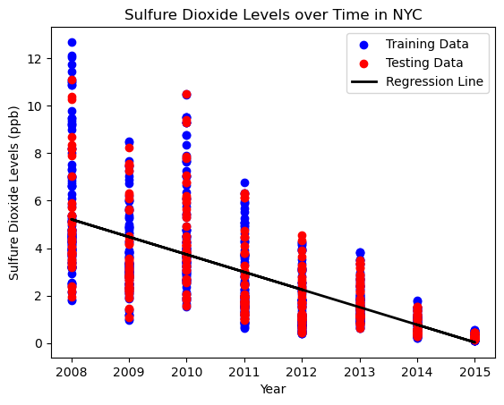

```
RANSAC
Coefficients:  [-0.57209305]
Intercept:  [1152.88977471]
Mean squared error: 3.24
Coefficient of determination: 0.43
```

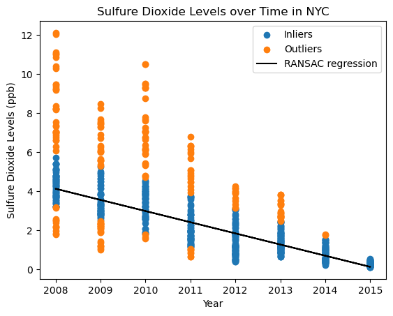

```python
X = SO2[['Year']]
Y = SO2[['Data Value']]
leastSquares(SO2, X, Y, 'Year', 'Sulfure Dioxide Levels (ppb)', 'Sulfure Dioxide Levels over Time in NYC')
RANSAC(SO2, X, Y, 'Year', 'Sulfure Dioxide Levels (ppb)', 'Sulfure Dioxide Levels over Time in NYC')
```

```
Ordinary Least Squares (OLS)
Coefficients:  [-0.78708131]
Intercept:  [1606.51362189]
Mean squared error: 32.28
Coefficient of determination: 0.16
```

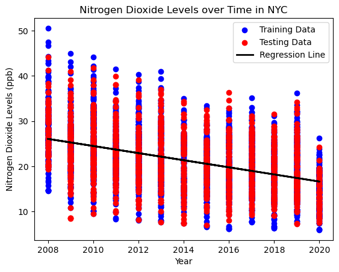

```
RANSAC
Coefficients:  [-0.42291063]
Intercept:  [872.76341732]
Mean squared error: 34.29
Coefficient of determination: 0.15
```

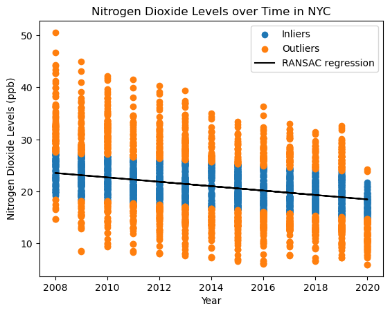

```python
X = NO2[['Year']]
Y = NO2[['Data Value']]
leastSquares(NO2, X, Y, 'Year', 'Nitrogen Dioxide Levels (ppb)', 'Nitrogen Dioxide Levels over Time in NYC')
RANSAC(SO2, X, Y, 'Year', 'Nitrogen Dioxide Levels (ppb)', 'Nitrogen Dioxide Levels over Time in NYC')
```

```
Ordinary Least Squares (OLS)
Coefficients:  [-0.40847969]
Intercept:  [832.18725872]
Mean squared error: 2.10
Coefficient of determination: 0.48
```

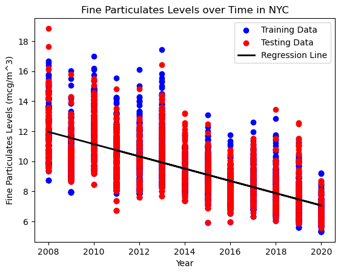

```
RANSAC
Coefficients:  [-0.31544671]
Intercept:  [644.3377474]
Mean squared error: 2.30
Coefficient of determination: 0.43
```

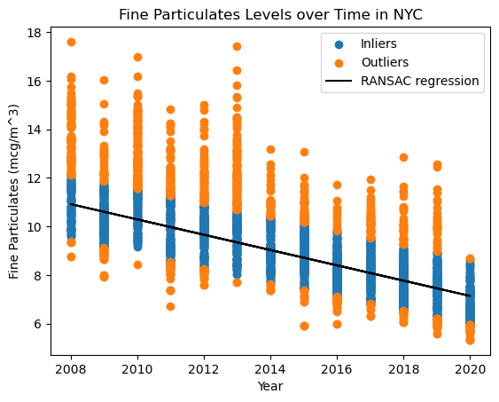

```python
X = PM2[['Year']]
Y = PM2[['Data Value']]
leastSquares(PM2, X, Y, 'Year', 'Fine Particulates Levels (mcg/m^3)', 'Fine Particulates Levels over Time in NYC')
RANSAC(PM2, X, Y, 'Year', 'Fine Particulates (mcg/m^3)', 'Fine Particulates Levels over Time in NYC')
```

Continuing on, let us do the same for the asthma emergency visits

```
Ordinary Least Squares (OLS)
Coefficients:  [0.51918064]
Intercept:  [-990.47613256]
Mean squared error: 1389.46
Coefficient of determination: -0.05
```

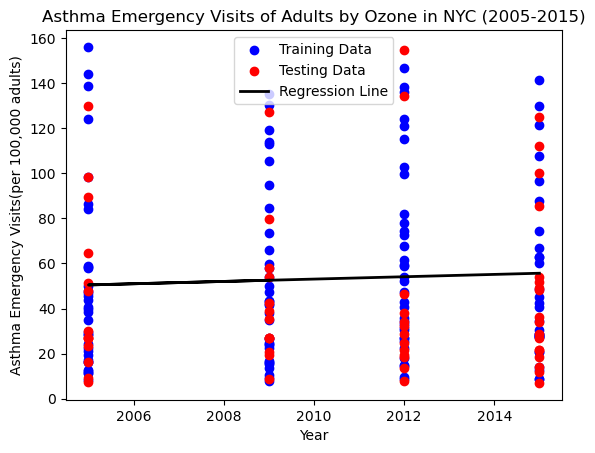

```
RANSAC
Coefficients:  [0.33970087]
Intercept:  [-660.11711865]
Mean squared error: 1978.72
Coefficient of determination: -0.63
```

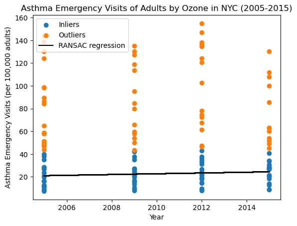

```
Ordinary Least Squares (OLS)
Coefficients:  [0.83664177]
Intercept:  [-1574.96092064]
Mean squared error: 3153.94
Coefficient of determination: -0.31
```

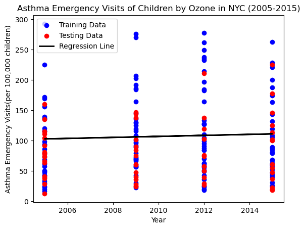

```
RANSAC
Coefficients:  [-1.87942231]
Intercept:  [3835.1894543]
Mean squared error: 7246.75
Coefficient of determination: -0.59
```

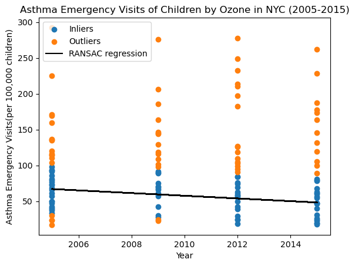

```python
asthma_adults = O3_asthma[O3_asthma['Measure'] == 'Estimated Annual Rate- 18 Yrs and Older']
asthma_child = O3_asthma[O3_asthma['Measure'] == 'Estimated Annual Rate- Children 0 to 17 Yrs Old']

X = asthma_adults[['Year']]
Y = asthma_adults[['Data Value']]
leastSquares(asthma_adults, X, Y, 'Year', 'Asthma Emergency Visits(per 100,000 adults)',
            'Asthma Emergency Visits of Adults by Ozone in NYC (2005-2015)')
RANSAC(asthma_adults, X, Y, 'Year', 'Asthma Emergency Visits (per 100,000 adults)',
            'Asthma Emergency Visits of Adults by Ozone in NYC (2005-2015)')

X = asthma_child[['Year']]
Y = asthma_child[['Data Value']]
leastSquares(asthma_child, X, Y, 'Year', 'Asthma Emergency Visits(per 100,000 children)',
            'Asthma Emergency Visits of Children by Ozone in NYC (2005-2015)')
RANSAC(asthma_child, X, Y, 'Year', 'Asthma Emergency Visits(per 100,000 children)',
            'Asthma Emergency Visits of Children by Ozone in NYC (2005-2015)')
```